# 2. EDA

### 2.1. Import Modules

Import relevant modules in one place.

```python
import numpy as np
import pandas as pd
import statsmodels.api as sm

import seaborn as sns
sns.set(rc={'figure.figsize':(16,8)}) # set the figure size for all sns plots
sns.set_style('whitegrid')

import matplotlib.pyplot as plt
from matplotlib.axes._axes import _log as matplotlib_axes_logger
matplotlib_axes_logger.setLevel('ERROR') # to hide matplot lib errors
```

### 2.2 Read Data

```python
path = 'data/bitcoin.csv'
df = pd.read_csv(path)
df.info()
```

```
<class 'pandas.core.frame.DataFrame'>
RangeIndex: 4216 entries, 0 to 4215
Data columns (total 2 columns):
 #   Column  Non-Null Count  Dtype
---  ------  --------------  -----
 0   date    4216 non-null   object
 1   close   4216 non-null   float64
dtypes: float64(1), object(1)
memory usage: 66.0+ KB
```

#### 2.2.1 Change column names

```python
# Column names: remove white spaces, convert to lower case, add _ instead of space
df.columns = df.columns.str.strip().str.lower().str.replace(' ','_')
df.head()
```

|  | date | close |
| --- | --- | --- |
| 0 | 2009/10/05 | 0.000764 |
| 1 | 2009/10/06 | 0.000885 |
| 2 | 2009/10/07 | 0.001050 |
| 3 | 2009/10/08 | 0.001084 |
| 4 | 2009/10/09 | 0.001200 |

#### 2.2.2 Change data types

```python
# convert date to datetime
df['date'] = pd.to_datetime(df['date'])
df.dtypes
```

```
date     datetime64[ns]
close           float64
dtype: object
```

### 2.3 Exploratory data information

#### 2.3.1 The number of rows and columns in dataset(s)

```python
# dimentions
df.shape
```

```
(4216, 2)
```

```python
# count
df.count()
```

```
date     4216
close    4216
dtype: int64
```

```python
# glimpse
df.head()
```

|  | date | close |
| --- | --- | --- |
| 0 | 2009-10-05 | 0.000764 |
| 1 | 2009-10-06 | 0.000885 |
| 2 | 2009-10-07 | 0.001050 |
| 3 | 2009-10-08 | 0.001084 |
| 4 | 2009-10-09 | 0.001200 |

```python
# describe
df.describe()
```

|  | close |
| --- | --- |
| count | 4216.000000 |
| mean | 3983.604844 |
| std | 8502.061444 |
| min | 0.000613 |
| 25% | 11.885000 |
| 50% | 447.022100 |
| 75% | 6259.965350 |
| max | 63564.833300 |

#### 2.3.2 The variable names

- `date` - This timestamp is converted to NY EST Standard Time
- `close` - This is the closing price of the time period

#### 2.3.3 The data types associated with each variable

```python
df.dtypes
```

```
date     datetime64[ns]
close           float64
dtype: object
```

#### 2.3.4 Number of missing values per variable

```python
# missing values
df.isna().sum()
```

```
date     0
close    0
dtype: int64
```

#### 2.3.5 Number of unique values per variable

```python
# unique values
df.nunique()
```

```
date     4216
close    3984
dtype: int64
```

*Interestingly enough, we have some mathcing prices.*

```python
# count unique values
pd.value_counts(df['close'])
```

```
0.005472       54
0.000718       16
0.003000       10
0.004485        9
0.005000        8
               ..
8.640000        1
2838.810000     1
686.520000      1
448.879200      1
375.848900      1
Name: close, Length: 3984, dtype: int64
```

*The matching prices seem to be from the early times when bitcoin was not big.*

#### 2.3.6 State which variables will be considered as INPUTS and OUTPUTS to a predictive model

Since this is a forecasing problem, I will be using historical `date` and `close` values to predict the future `close` value.

### 2.4 Visualizations without Transformations

```python
df = df.set_index('date') # set index
```

```python
# create new columns from datetime index
df['year'] = df.index.year
df['month'] = df.index.month
df['day'] = df.index.day
df.head()
```

| date | close | year | month | day |
| --- | --- | --- | --- | --- |
| 2009-10-05 | 0.000764 | 2009 | 10 | 5 |
| 2009-10-06 | 0.000885 | 2009 | 10 | 6 |
| 2009-10-07 | 0.001050 | 2009 | 10 | 7 |
| 2009-10-08 | 0.001084 | 2009 | 10 | 8 |
| 2009-10-09 | 0.001200 | 2009 | 10 | 9 |

```python
df = df.loc['2009-11-01':'2021-03-31'] # subset to have complete data on all months
df.head()
```

| date | close | year | month | day |
| --- | --- | --- | --- | --- |
| 2009-11-01 | 0.001219 | 2009 | 11 | 1 |
| 2009-11-02 | 0.001256 | 2009 | 11 | 2 |
| 2009-11-03 | 0.001273 | 2009 | 11 | 3 |
| 2009-11-04 | 0.001306 | 2009 | 11 | 4 |
| 2009-11-05 | 0.001306 | 2009 | 11 | 5 |

```python
daily_series = df['close'].copy()
daily_series.head()
```

```
date
2009-11-01    0.001219
2009-11-02    0.001256
2009-11-03    0.001273
2009-11-04    0.001306
2009-11-05    0.001306
Name: close, dtype: float64
```

```python
weekly_series = df['close'].copy().resample('W').last()
weekly_series.head()
```

```
date
2009-11-01    0.001219
2009-11-08    0.001260
2009-11-15    0.001236
2009-11-22    0.001059
2009-11-29    0.000829
Freq: W-SUN, Name: close, dtype: float64
```

```python
monthly_series = df['close'].copy().resample('MS').last()
monthly_series.head()
```

```
date
2009-11-01    0.000824
2009-12-01    0.000689
2010-01-01    0.003298
2010-02-01    0.005298
2010-03-01    0.005472
Freq: MS, Name: close, dtype: float64
```

##### 2.4.1 Lineplots

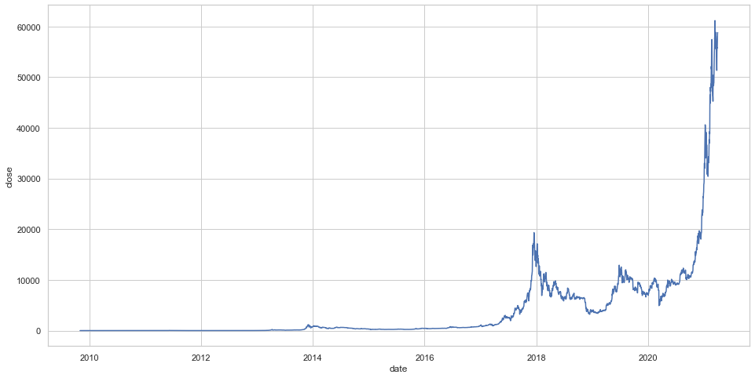

```python
# big lineplot
sns.lineplot(x='date', y='close', data=df)
plt.show()
```

*The Bitcoin price just skyrocketed in 2021!*

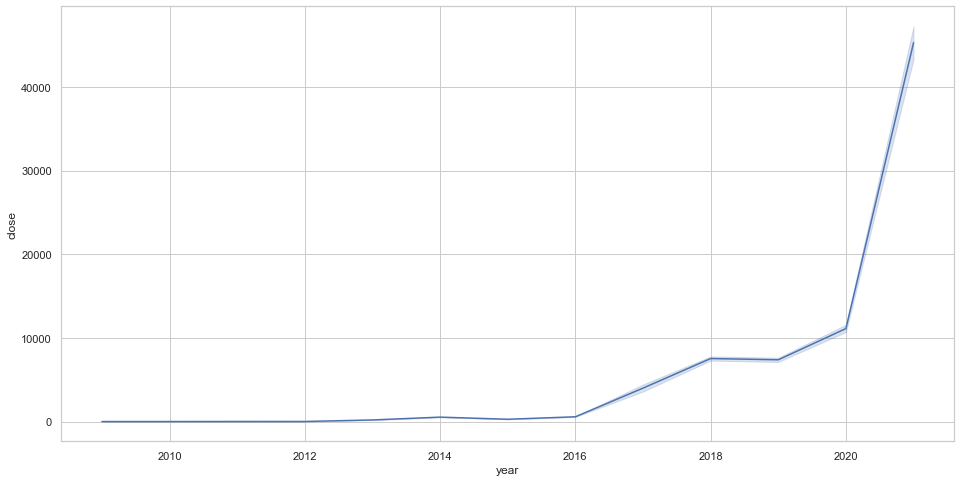

```python
# lineplot for years
sns.lineplot(x='year', y='close', data=df)
plt.show()
```

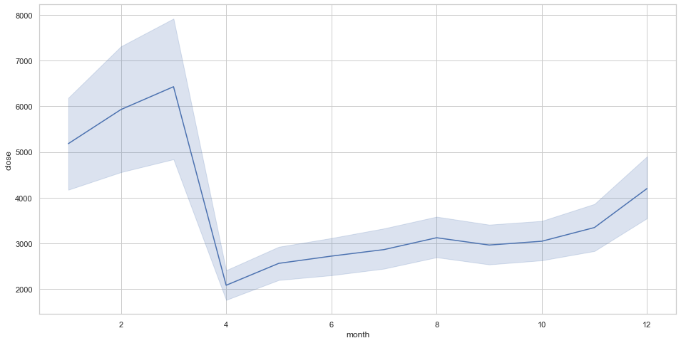

```python
# lineplot for months
sns.lineplot(x='month', y='close', data=df)
plt.show()
```

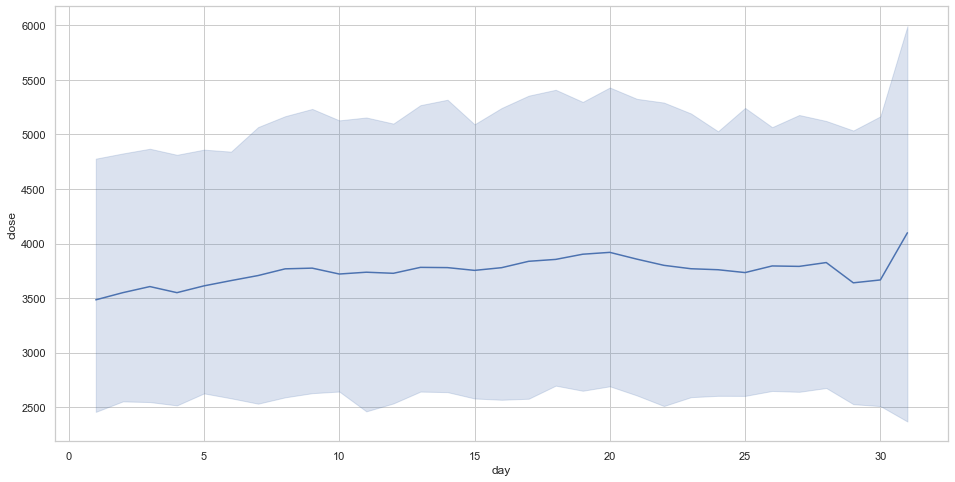

```python
# lineplot for days
sns.lineplot(x='day', y='close', data=df)
plt.show()
```

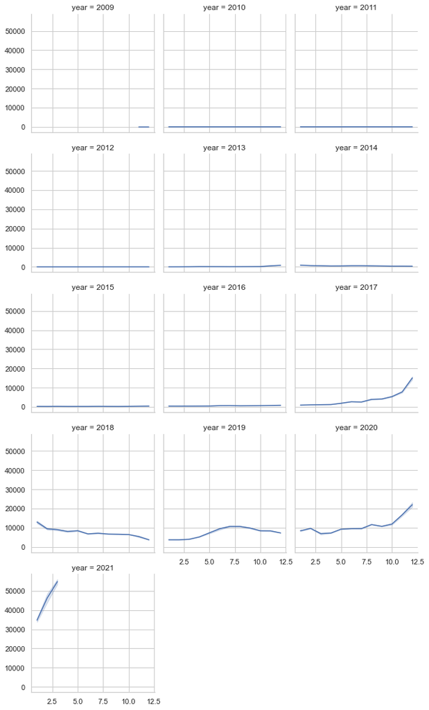

```python
# month by year
g = sns.FacetGrid(data=df, col='year', col_wrap=3)
g.map_dataframe(sns.lineplot, x='month', y='close')
plt.show()
```

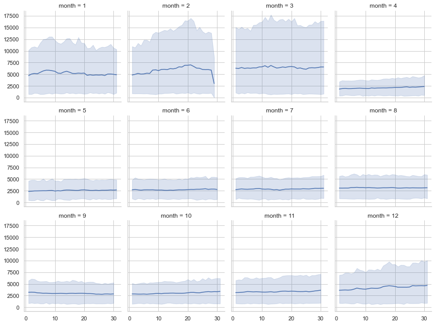

```python
# day by month
g = sns.FacetGrid(data=df, col='month', col_wrap=4)
g.map_dataframe(sns.lineplot, x='day', y='close')
plt.show()
```

##### 2.4.2 Boxplots

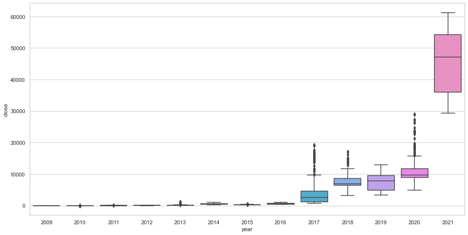

```python
# boxplots by year
sns.boxplot(x='year', y='close', data=df)
plt.show()
```

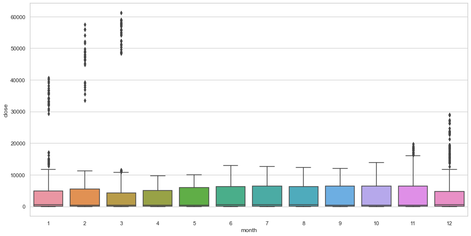

```python
# boxplots by month
sns.boxplot(x='month', y='close', data=df)
plt.show()
```

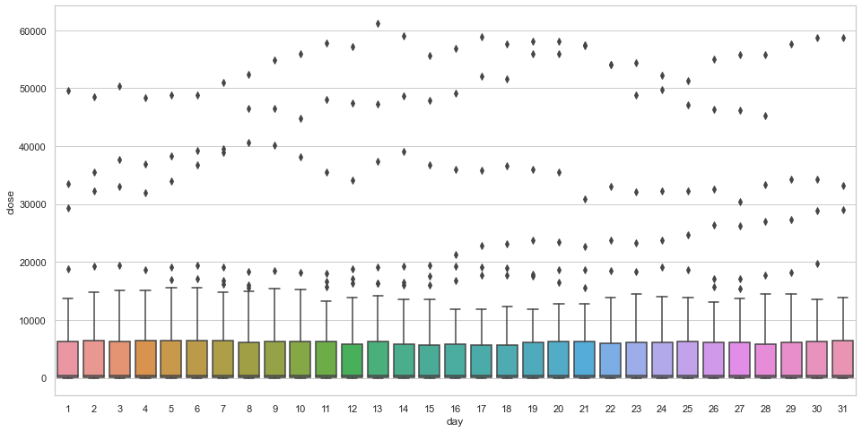

```python
# boxplots by day
sns.boxplot(x='day', y='close', data=df)
plt.show()
```

##### 2.4.3 Violin Plots

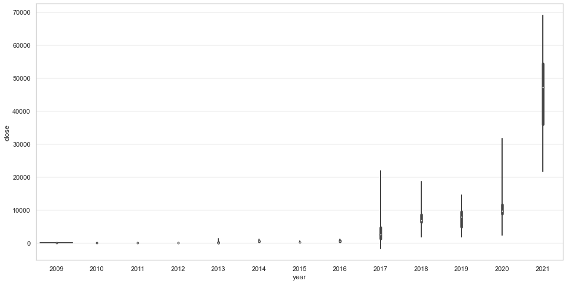

```python
# violinplots by year
sns.violinplot(x='year', y='close', data=df)
plt.show()
```

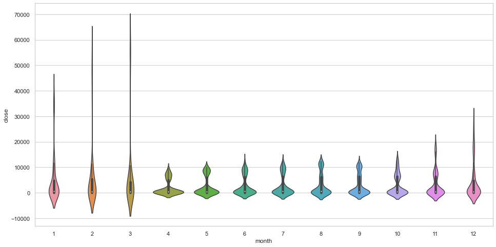

```python
# violinplots by month
sns.violinplot(x='month', y='close', data=df)
plt.show()
```

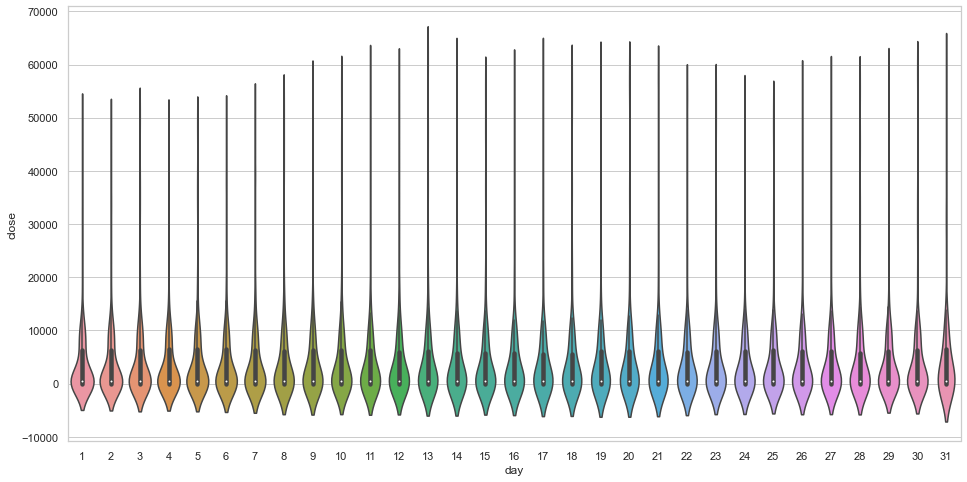

```python
# violinplots by day
sns.violinplot(x='day', y='close', data=df)
plt.show()
```

##### 2.4.4 Barplots

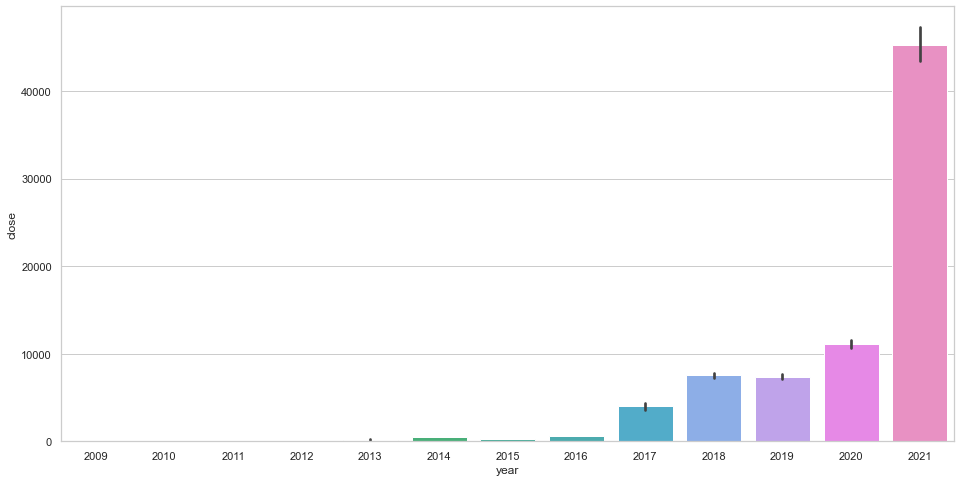

```python
# barplots by year
sns.barplot(x='year', y='close', data=df)
plt.show()
```

*Even though 2021 just started, the average closing price is already a few times higher than in 2020!*

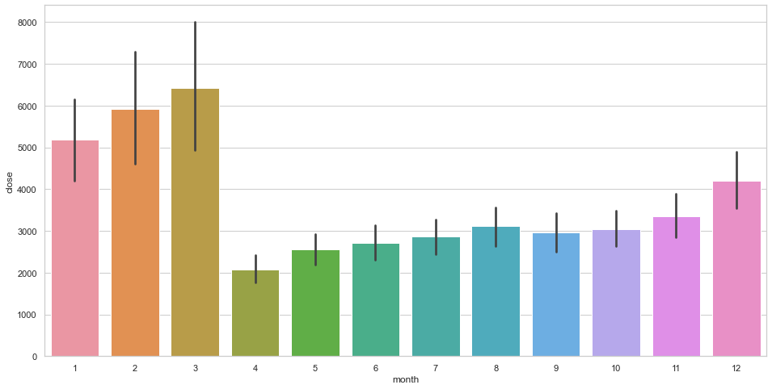

```python
# barplots by month
sns.barplot(x='month', y='close', data=df)
plt.show()
```

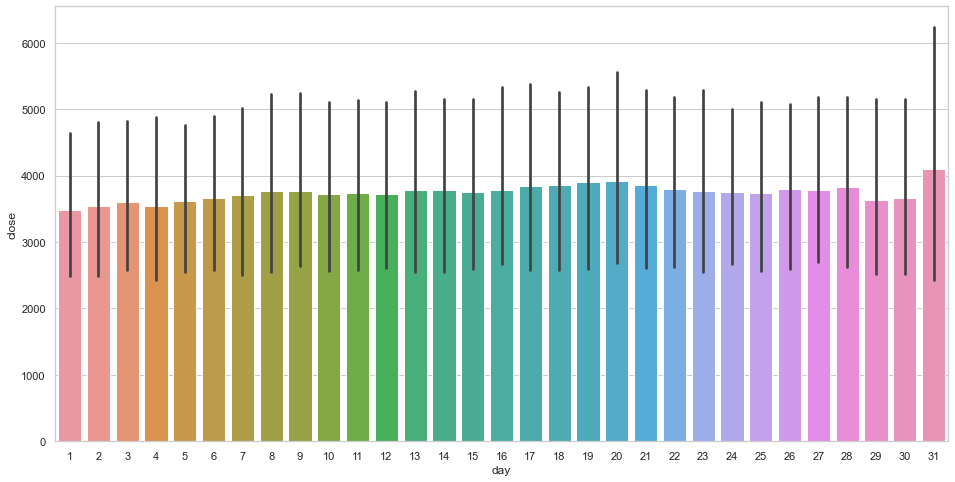

```python
# barplots by day
sns.barplot(x='day', y='close', data=df)
plt.show()
```

##### LOG Transformation!

`close` is log-transfoirmed closing price. I chose to keep it as 'close' to avoid changing all the code. `close_orig` is original closing price.

```python
df['close_orig'] = df['close']
df['close'] = np.log(df['close'])
df.head()
```

| date | close | year | month | day | close_orig |
| --- | --- | --- | --- | --- | --- |
| 2009-11-01 | -6.709724 | 2009 | 11 | 1 | 0.001219 |
| 2009-11-02 | -6.679823 | 2009 | 11 | 2 | 0.001256 |
| 2009-11-03 | -6.666379 | 2009 | 11 | 3 | 0.001273 |
| 2009-11-04 | -6.640786 | 2009 | 11 | 4 | 0.001306 |
| 2009-11-05 | -6.640786 | 2009 | 11 | 5 | 0.001306 |

#### 2.4.5 Lag plots

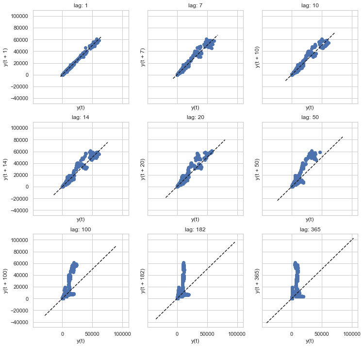

```python
# daily
lags_use = [1, 7, 10, 14, 20, 50, 100, 182, 365]

fig, ax = plt.subplots(3, 3, figsize=(12, 12), sharex=True, sharey=True)

ax = ax.ravel()

for k in range(len(lags_use)):
    pd.plotting.lag_plot( daily_series, lag=lags_use[k], ax=ax[k] )
    ax[k].plot( ax[k].get_xlim(), ax[k].get_ylim(), 'k--')
    ax[k].set_title('lag: ' + str(lags_use[k]) )

plt.show()
```

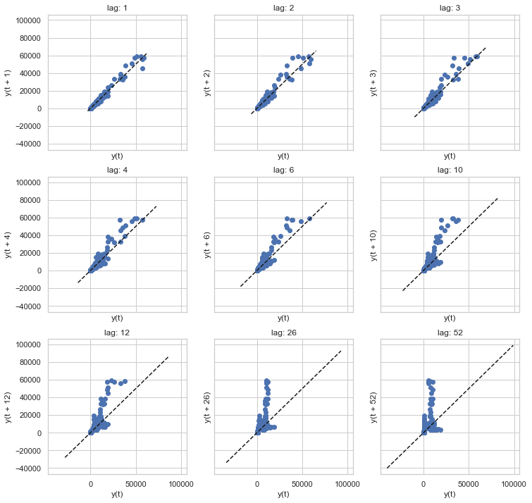

```python
# weekly
lags_use = [1, 2, 3, 4, 6, 10, 12, 26, 52]

fig, ax = plt.subplots(3, 3, figsize=(12, 12), sharex=True, sharey=True)

ax = ax.ravel()

for k in range(len(lags_use)):
    pd.plotting.lag_plot( weekly_series, lag=lags_use[k], ax=ax[k] )
    ax[k].plot( ax[k].get_xlim(), ax[k].get_ylim(), 'k--')
    ax[k].set_title('lag: ' + str(lags_use[k]) )

plt.show()
```

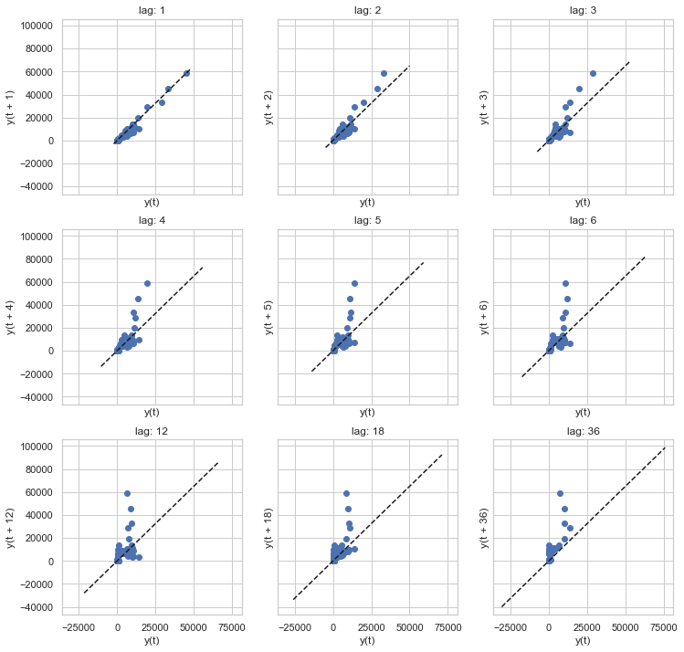

```python
# monthly
lags_use = [1, 2, 3, 4, 5, 6, 12, 18, 36]

fig, ax = plt.subplots(3, 3, figsize=(12, 12), sharex=True, sharey=True)

ax = ax.ravel()

for k in range(len(lags_use)):
    pd.plotting.lag_plot( monthly_series, lag=lags_use[k], ax=ax[k] )
    ax[k].plot( ax[k].get_xlim(), ax[k].get_ylim(), 'k--')
    ax[k].set_title('lag: ' + str(lags_use[k]) )

plt.show()
```

#### 2.4.6 Autocorrelation plots

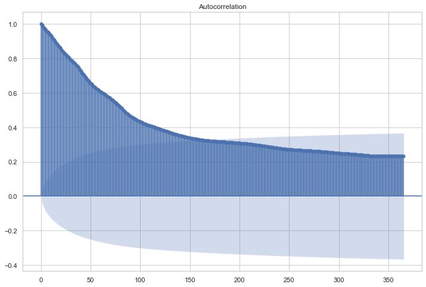

```python
# daily - year
fig, ax = plt.subplots( figsize = (12, 8) )
sm.graphics.tsa.plot_acf( daily_series.values.squeeze(),
                         lags=365, ax = ax)
plt.show()
```

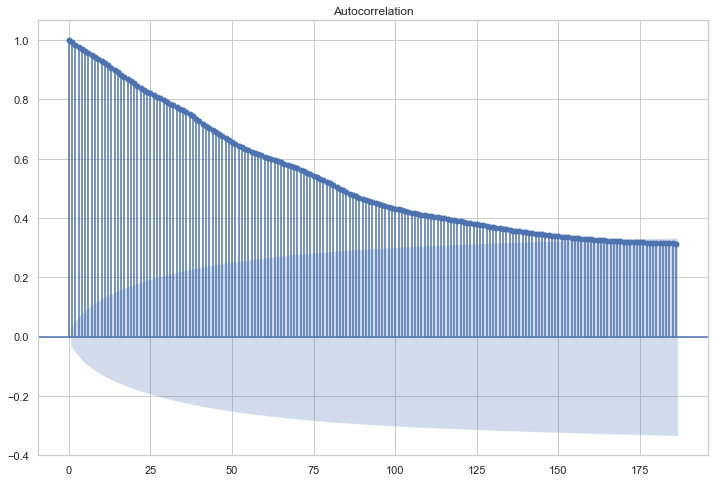

```python
# daily - half year
fig, ax = plt.subplots( figsize = (12, 8) )
sm.graphics.tsa.plot_acf( daily_series.values.squeeze(),
                         lags=186, ax = ax)
plt.show()
```

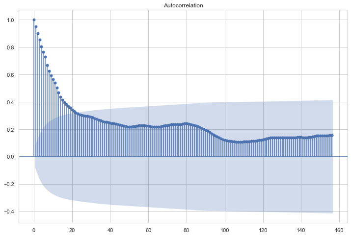

```python
# weekly - 3 years
fig, ax = plt.subplots( figsize = (12, 8) )
sm.graphics.tsa.plot_acf( weekly_series.values.squeeze(),
                         lags=52*3, ax = ax)
plt.show()
```

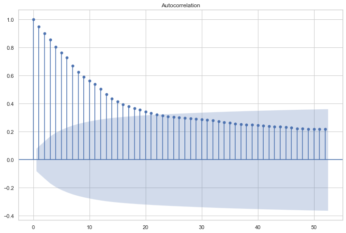

```python
# weekly - 1 year
fig, ax = plt.subplots( figsize = (12, 8) )
sm.graphics.tsa.plot_acf( weekly_series.values.squeeze(),
                         lags=52, ax = ax)
plt.show()
```

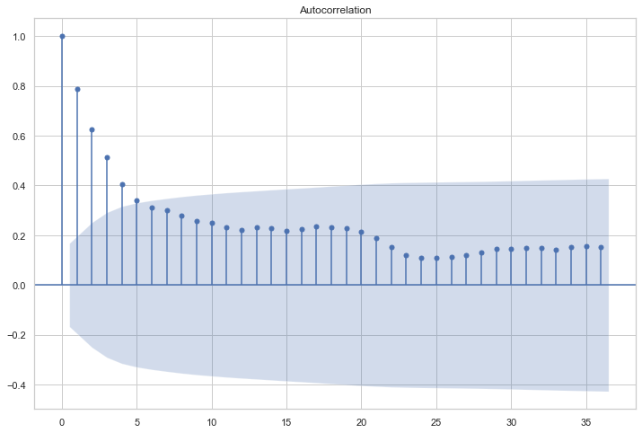

```python
# monthly - 3 years
fig, ax = plt.subplots( figsize = (12, 8) )
sm.graphics.tsa.plot_acf( monthly_series.values.squeeze(),
                         lags=12*3, ax = ax)
plt.show()
```

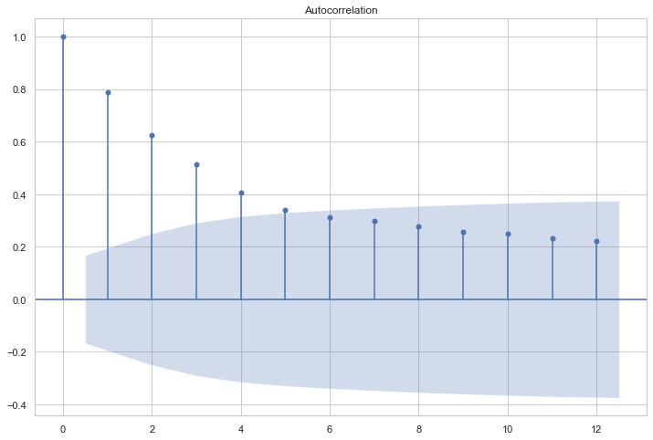

```python
# monthly - 1 year
fig, ax = plt.subplots( figsize = (12, 8) )
sm.graphics.tsa.plot_acf( monthly_series.values.squeeze(),
                         lags=12, ax = ax)
plt.show()
```

#### 2.4.7 Time Series Decomposition

##### Weekly

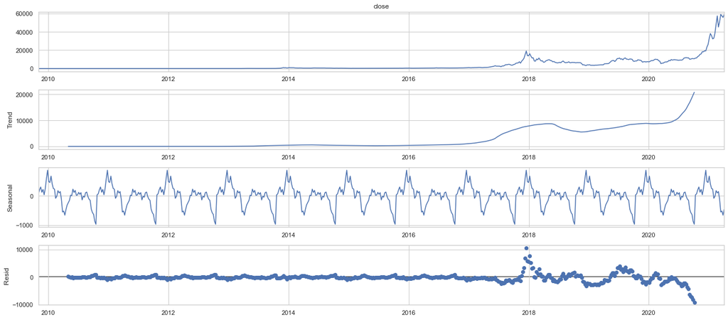

```python
# weekly - full data
weekly_decomposition = sm.tsa.seasonal_decompose(
    weekly_series, model='additive')

plt.rcParams['figure.figsize'] = 18,8
plt.show()

fig = weekly_decomposition.plot()
```

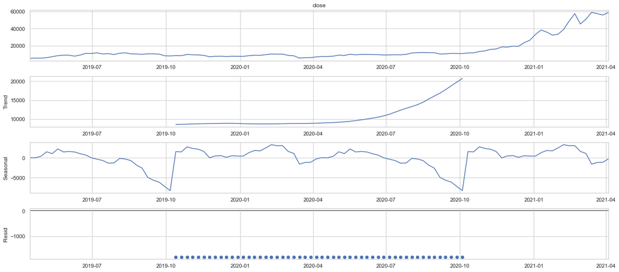

```python
# weekly - last 2 years
weekly_decomposition_2y = sm.tsa.seasonal_decompose(
    weekly_series[-104:], model='additive') # subsetting from the end

plt.rcParams['figure.figsize'] = 18,8
plt.show()

fig = weekly_decomposition_2y.plot()
```

*Compare the observed and seasonally adjusted trends.*

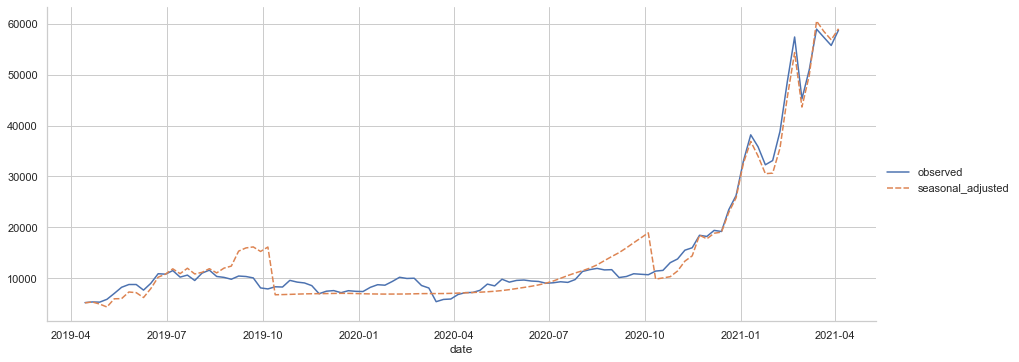

```python
weekly_2y_decomp = pd.DataFrame({
    'observed': weekly_decomposition_2y.observed,
    'seasonal_adjusted': weekly_decomposition_2y.observed - weekly_decomposition_2y.seasonal
    },
    index=weekly_series[-104:].index)

sns.relplot( data=weekly_2y_decomp, kind='line', aspect=2.5 )
plt.show()
```

##### Monthly

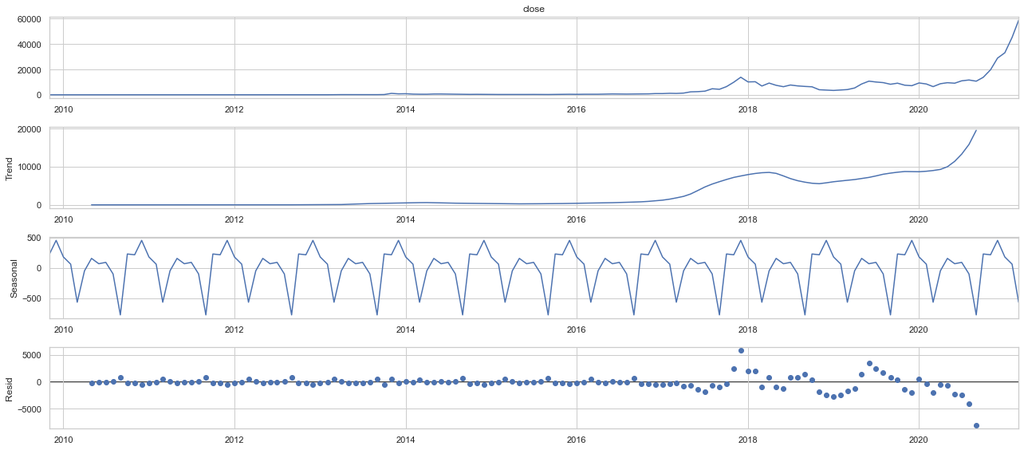

```python
# monthly - full data
monthly_decomposition = sm.tsa.seasonal_decompose(
    monthly_series, model='additive')

plt.rcParams['figure.figsize'] = 18,8
plt.show()

fig = monthly_decomposition.plot()
```

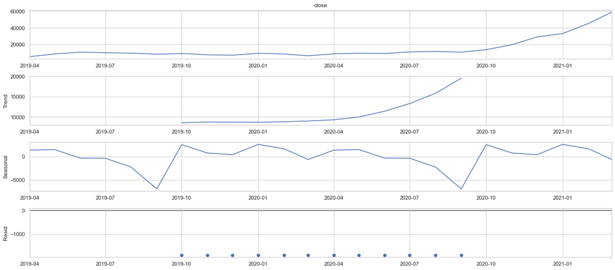

```python
# monthly - last 2 years
monthly_decomposition_2y = sm.tsa.seasonal_decompose(
    monthly_series[-24:], model='additive')

plt.rcParams['figure.figsize'] = 18,8
plt.show()

fig = monthly_decomposition_2y.plot()
```

*Compare the observed and seasonally adjusted trends.*

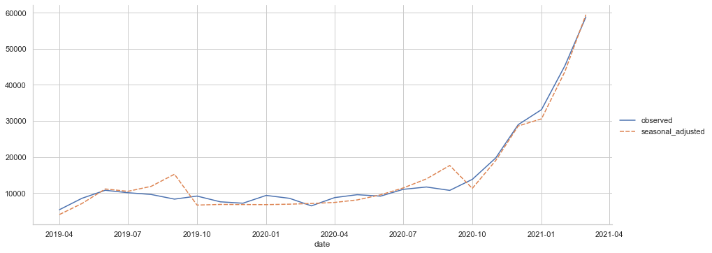

```python
monthly_2y_decomp = pd.DataFrame({
    'observed': monthly_decomposition_2y.observed,
    'seasonal_adjusted': monthly_decomposition_2y.observed - monthly_decomposition_2y.seasonal
    },
    index=monthly_series[-24:].index)

sns.relplot( data=monthly_2y_decomp, kind='line', aspect=2.5 )
plt.show()
```

### 2.4 Quick EDA for Exogenous

Read in thre data.

```python
path = 'data/exogenous.csv'
df_exo = pd.read_csv(path)
df_exo.info()
```

```
<class 'pandas.core.frame.DataFrame'>
RangeIndex: 2846 entries, 0 to 2845
Data columns (total 7 columns):
 #   Column  Non-Null Count  Dtype
---  ------  --------------  -----
 0   date    2846 non-null   object
 1   gold    2846 non-null   float64
 2   oil     2846 non-null   float64
 3   spx     2846 non-null   float64
 4   vfh     2846 non-null   float64
 5   vgt     2846 non-null   float64
 6   nvda    2846 non-null   float64
dtypes: float64(6), object(1)
memory usage: 155.8+ KB
```

Change Indexing

```python
# convert date to datetime
df_exo['date'] = pd.to_datetime(df_exo['date'])
df_exo.dtypes
```

```
date    datetime64[ns]
gold           float64
oil            float64
spx            float64
vfh            float64
vgt            float64
nvda           float64
dtype: object
```

```python
df_exo = df_exo.set_index('date') # set index
```

```python
df_exo
```

| date | gold | oil | spx | vfh | vgt | nvda |
| --- | --- | --- | --- | --- | --- | --- |
| 2009-11-02 | 1053.400024 | 78.129997 | 1042.88 | 28.270000 | 49.459999 | 12.070000 |
| 2009-11-03 | 1084.300049 | 79.599998 | 1045.41 | 28.379999 | 49.450001 | 12.010000 |
| 2009-11-04 | 1086.699951 | 80.400002 | 1046.50 | 28.030001 | 49.770000 | 11.980000 |
| 2009-11-05 | 1088.699951 | 79.620003 | 1066.63 | 28.660000 | 50.930000 | 12.270000 |
| 2009-11-06 | 1095.099976 | 77.430000 | 1069.30 | 28.559999 | 51.020000 | 13.160000 |
| ... | ... | ... | ... | ... | ... | ... |
| 2021-03-25 | 1724.900024 | 58.560001 | 3909.52 | 84.370003 | 349.890015 | 501.410004 |
| 2021-03-26 | 1732.199951 | 60.970001 | 3974.54 | 85.410004 | 357.589996 | 513.570007 |
| 2021-03-29 | 1712.099976 | 61.560001 | 3971.09 | 84.430000 | 354.899994 | 517.929993 |
| 2021-03-30 | 1683.900024 | 60.549999 | 3958.55 | 85.190002 | 352.649994 | 514.869995 |
| 2021-03-31 | 1713.800049 | 59.160000 | 3972.89 | 84.500000 | 358.489990 | 533.929993 |

2846 rows × 6 columns

Visualize.

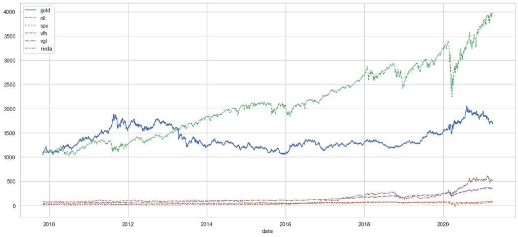

```python
# big lineplot
sns.lineplot(data=df_exo)
plt.show()
```

*Might want to transform the exogenous variables as well.*